[output not shown]

# Resumen

# Motivación y objetivo del estudio

Se busca crear un indicador de una posible crisis bursátil. Como variable de referencia de toma la relación de precios al cierre de ayer sobre la de hoy

$$\begin{equation}
Indicador_t=\frac{Precio_{t-1}}{Precio_t},\quad\text{para}\; t=1,...,T
\label{eq:ind}
\end{equation}$$

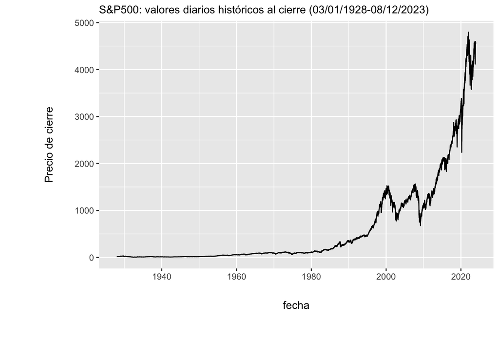

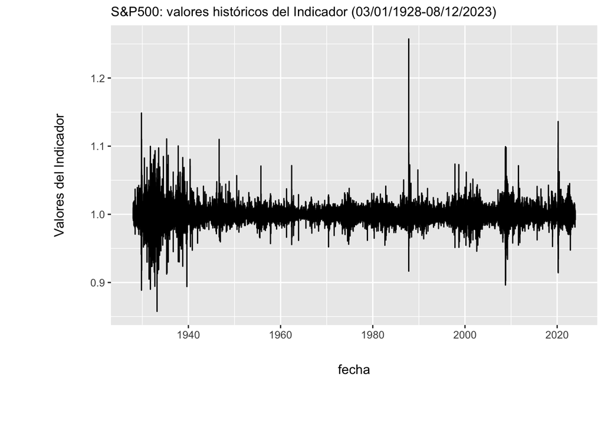

# Marco Teórico

## Teoría asintótica clásica y las distribuciones extremales y sus dominios de atracción

Siguiendo a @notas_curso se dice que tenemos datos extremos cuando cada dato corresponde al máximo o mínimo de varios registros. Son un caso particular de evento raro o gran desviación respecto a la media.

Asumiremos que nuestros datos son $iid$ (independientes e idénticamente distribuidos, son dos suposiciones juntas). Esta doble suposición suele no ser realista en aplicaciones concretas (ninguna de sus dos componentes, incluso) pero para comenzar a entender la teoría clásica, la utilizaremos por un tiempo.

Si tenemos datos $X_1,...,X_n$ $iid$ con distribución $F$, entonces $X_n^* = max (X_1,...,X_n)$ tiene distribución $F_n^*$ dada por $F_n^* (t)= F(t)_n$. Si conocemos la distribución $F$ conoceríamos la distribución $F_n^*$ , pero en algunos casos la lectura que queda registrada es la del dato máximo y no la de cada observación que dio lugar al mismo, por lo que a veces ni siquiera es viable estimar $F$. Pero aún en los casos en que $F$ es conocida o estimable, si $n$ es grande, la fórmula de $F_n^*$ puede resultar prácticamente inmanejable. En una línea de trabajo similar a la que aporta el Teorema Central del Límite en la estadística de valores medios, un teorema nos va a permitir aproximar $F_n^*$ por distribuciones más sencillas. Este es el Teorema de Fischer-Tippet-Gnedenko (FTG, para abreviar) que presentaremos en breve.

Como $X_1,...,X_n$ iid, definimos $Y_i = -X_i$ para todo valor de $i$, entonces $Y_1,...,Y_n$ iid y además $min(X_1,...,X_n) = - max(Y_1,...,Y_n)$ la teoría asintótica de los mínimos de datos iid se reduce a la de los máximos, razón por la que nos concentramos aquí en estudiar el comportamiento asintótico de los máximos exclusivamente.

### Definición 1: Las distribuciones extremales

Las distribuciones extremales son tres: la distribución de Gumbel; la distribución de Weibull; la distribución de Fréchet.

#### Distribución de Gumbel

Se dice que una variable tiene distribución de Gumbel si su distribución es:

$$\Lambda(x) = exp\{-e^{-x}\}
\quad\text{para todo}\; x \;\text{real}$$

#### Distribución de Weibull

Se dice que una variable tiene distribución de Weibull de orden $\alpha>0$ si su distribución es:

$$\Psi_{\alpha}(x)=\begin{cases}
exp{-(-x)^{\alpha}} & si\;x<0\\
1 & \text{en otro caso}
\end{cases}$$

#### Distribución de Fréchet

Se dice que una variable tiene distribución de Fréchet de orden $\alpha>0$ si su distribución es:

$$\Phi_{\alpha}(x)=\begin{cases}
exp\{-x^{-\alpha}\} & si\;x>0\\
0 & \text{en otro caso}
\end{cases}$$

##### Teorema 1: Relaciones entre las versiones standard de las distribuciones extremales

$X$ tiene distribución $\Phi_{\alpha}(x)$ si y sólo si $(-1/X)$ tiene distribución $\Psi_{\alpha}(x)$ si y sólo si $log(X^{\alpha})$ tiene distribución $\Lambda$.

#### Parte 2

##### Teorema 3: Fischer-Tippet-Gnedenko (FTG)

Más precisamente, cuál de las tres aproximaciones es la aplicable depende de la cola de $F$ (los valores de $F(t)$ para valores grandes de $t$). En concreto, Weibull aparece cuando $F$ es la distribución de una variable acotada por arriba (como la Uniforme), Gumbel para distribuciones de variables no acotadas por arriba pero con colas muy livianas (caso Exponencial y Normal) y Fréchet para colas pesadas (caso Cauchy).

Se emplea la prueba de ajuste $\chi^2$ que requiere seleccionar una partición más o menos arbitraria de la recta real de intervalos siendo importante que en cada intervalo haya una cantidad lo suficientemente importante de datos de la muestra. En este sentido, se pueden tomar como extremos de los intervalos los quintiles empíricos de la muestra. Cabe mencionar que este test requiere estimar parámetros por el método de Máxia Verosimilitud Categórica.

Cabe mencionar que para este estudio la distribución de la variable a incorporar en este estudio no tiene que ser degenerada, es decir $H(t)=0$ ó $H(t)=1$.

### Definición 2: Distribución extremal asintótica

Si $X_1,...,X_n$ es $iid$ con distribución $F$ diremos que $H$ no-degenerada es la Distribución Extremal Asintótica (DEA) de $F$, si existen dos sucesiones de números reales, $d_n$ y $c_n>0$, tales que la distribución de

$$\begin{equation}
\frac{max(X_1,...,X_n)- d_n}{c_n}\label{eq:max}
\end{equation}$$

tiende a $H$ cuando $n$ tiende a infinito.